# Caso Euromotors

#Descripción del problema

En este notebook les mostraré paso a paso el análisis del problema propuesto. El objetivo de este problema es la resolución de las siguientes incógnitas:

1. ¿Cómo son los clientes de lujo para enfocar las estrategias de marketing?
   - Seleccionar las 10 variables más importantes del dataset
   - ¿Son los precios similares a los de la realidad?
2. ¿Cómo hacer la campaña de marketing más efectiva?
   - Seleccionar las variables más relevantes
   - ¿De qué manera confirmaría que la propuesta es la adecuada?

```
## VIM is ready to use.
```

```
## Suggestions and bug-reports can be submitted at: https://github.com/statistikat/VIM/issues
```

###Lectura de datos del CSV

```r
db<-read.csv("Base de datos caso práctico.csv")

#View(db)

dim(db)
```

```
## [1] 5000  124
```

Son 5000 filas y 124 columnas

###Busqueda de duplicados

```r
n_occur<-data.frame(table(db$custid))
n_occur[n_occur$Freq>1,]
```

| Var1 | Freq |
| --- | --- |

No hay customers duplicados

###Cambio de variables categóricas a factors

```r
db$region<-as.factor(db$region)
db$townsize<-as.factor(db$townsize)
db$gender<-as.factor(db$gender)
db$agecat<-as.factor(db$agecat)
db$edcat<-as.factor(db$edcat)
db$jobcat<-as.factor(db$jobcat)
db$union<-as.factor(db$union)
db$empcat<-as.factor(db$empcat)
db$retire<-as.factor(db$retire)
db$inccat<-as.factor(db$inccat)
db$default<-as.factor(db$default)
db$jobsat<-as.factor(db$jobsat)
db$marital<-as.factor(db$marital)
db$spousedcat<-as.factor(db$spousedcat)
db$homeown<-as.factor(db$homeown)
db$hometype<-as.factor(db$hometype)
db$addresscat<-as.factor(db$addresscat)
db$carown<-as.factor(db$carown)
db$cartype<-as.factor(db$cartype)
db$carcatvalue<-as.factor(db$carcatvalue)
db$carbought<-as.factor(db$carbought)
db$carbuy<-as.factor(db$carbuy)
db$carcatvalue<-as.factor(db$carcatvalue)
db$commute<-as.factor(db$commute)
db$commutecat<-as.factor(db$commutecat)
db$commutecar<-as.factor(db$commutecar)
db$commuterail<-as.factor(db$commuterail)
db$commutebus<-as.factor(db$commutebus)
db$commutemotorcycle<-as.factor(db$commutemotorcycle)
db$commutepublic<-as.factor(db$commutepublic)
db$commutebike<-as.factor(db$commutebike)
db$commutewalk<-as.factor(db$commutewalk)
db$commutenonmotor<-as.factor(db$commutenonmotor)
db$telecommute<-as.factor(db$telecommute)
db$reason<-as.factor(db$reason)
db$birthmonth<-as.factor(db$birthmonth)
db$polview<-as.factor(db$polview)
db$polparty<-as.factor(db$polparty)
db$vote<-as.factor(db$vote)
db$card<-as.factor(db$card)
db$cardtype<-as.factor(db$cardtype)
db$cardbenefit<-as.factor(db$cardbenefit)
db$card2<-as.factor(db$card2)
db$card2type<-as.factor(db$card2type)
db$card2benefit<-as.factor(db$card2benefit)
db$active<-as.factor(db$active)
db$bfast<-as.factor(db$bfast)
db$churn<-as.factor(db$churn)
db$tollfree<-as.factor(db$tollfree)
db$equip<-as.factor(db$equip)
db$callcard<-as.factor(db$callcard)
db$wireless<-as.factor(db$wireless)
db$wiremon<-as.factor(db$wiremon)
db$multline<-as.factor(db$multline)
db$voice<-as.factor(db$voice)
db$pager<-as.factor(db$pager)
db$internet<-as.factor(db$internet)
db$callid<-as.factor(db$callid)
db$forward<-as.factor(db$forward)
db$confer<-as.factor(db$confer)
db$owntv<-as.factor(db$owntv)
db$ownvcr<-as.factor(db$ownvcr)
db$owndvd<-as.factor(db$owndvd)
db$owncd<-as.factor(db$owncd)
db$ownpda<-as.factor(db$ownpda)
db$ownpc<-as.factor(db$ownpc)
db$ownipod<-as.factor(db$ownipod)
db$owngame<-as.factor(db$owngame)
db$ownfax<-as.factor(db$ownfax)
db$news<-as.factor(db$news)
db$response_01<-as.factor(db$response_01)
db$response_02<-as.factor(db$response_02)
db$response_03<-as.factor(db$response_03)
```

Ahora veamos que columnas tienen una alta cantidad de valores nulos

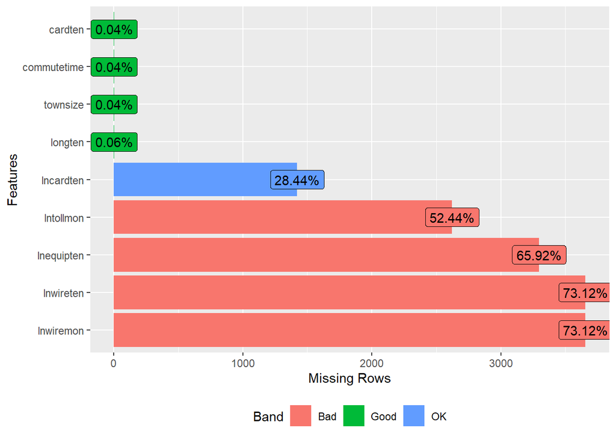

```r
plot_missing(db,missing_only = TRUE)
```

Se pasan a eliminar las columans con datos faltantes mayores al 20% (5 columnas)

```r
db<-db[, colMeans(is.na(db)) <= .2]
dim(db)
```

```
## [1] 5000  119
```

A continuación podemos ver las columnas que quedan con datos faltantes

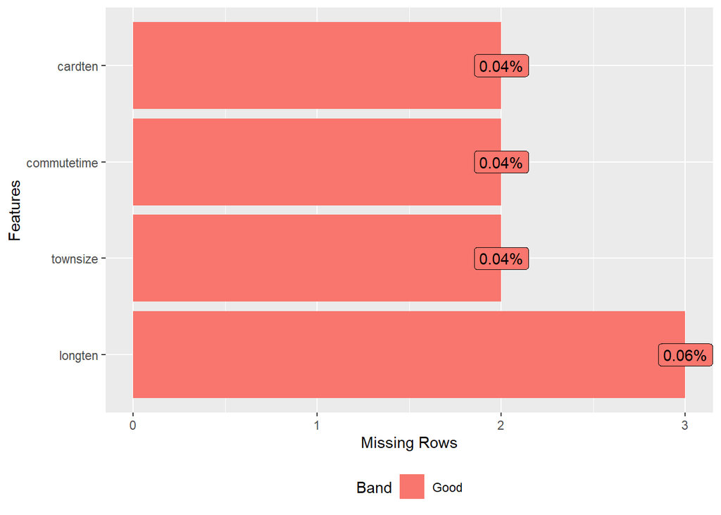

```r
plot_missing(db,missing_only = TRUE)
```

Ahora, se pasará a imputar estas columnas

```r
db<-kNN(db)
db<-db%>%select(-ends_with("_imp")) #Para eliminar las adicionales que se generan en la imputación
```

Finalmente, guardamos una copia de seguridad de los datos limpios

```r
write.csv(db,"db_clean.csv")
```